# Mixed Models

## 2.1 Diagnostics and Checks

Typical diagnostics and checks include checking for outliers, assessing whether the distributional assumptions are met, checking for homogeneity of variance and checking whether there is a linear association between predictors and outcome. With only an intercept, there is no need for checking whether a linear association is appropriate.

First we check for outliers on the residuals and the random intercept. These plots show some extreme values on the residuals and are somewhat unclear on the random intercept. In this case, using the scaled pearson residuals, which are roughly like z scores, the size of the residual outliers are not too big as to likely be an issue, particularly as we have thousands of observations.

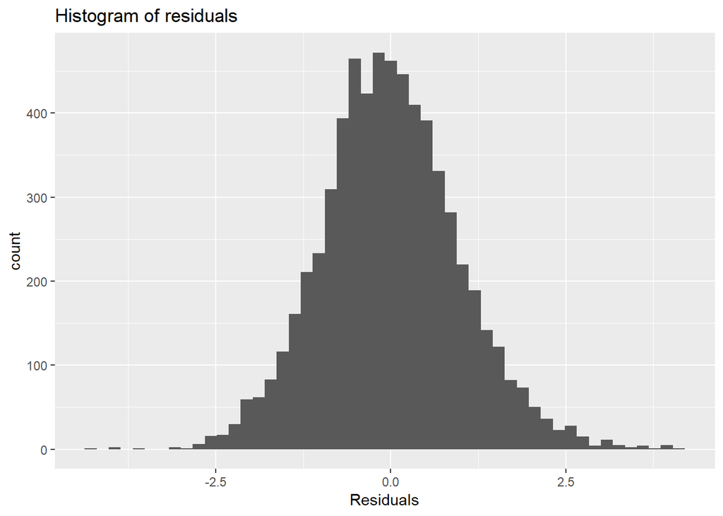

```r
res.d <- data.table(
  Residuals = residuals(ri.m, type = "pearson", scaled=TRUE),
  Yhat = fitted(ri.m))
ran.d <- as.data.table(ranef(ri.m))

ggplot(res.d, aes(Residuals)) +
  geom_histogram(bins = 50) +
  ggtitle("Histogram of residuals")
```

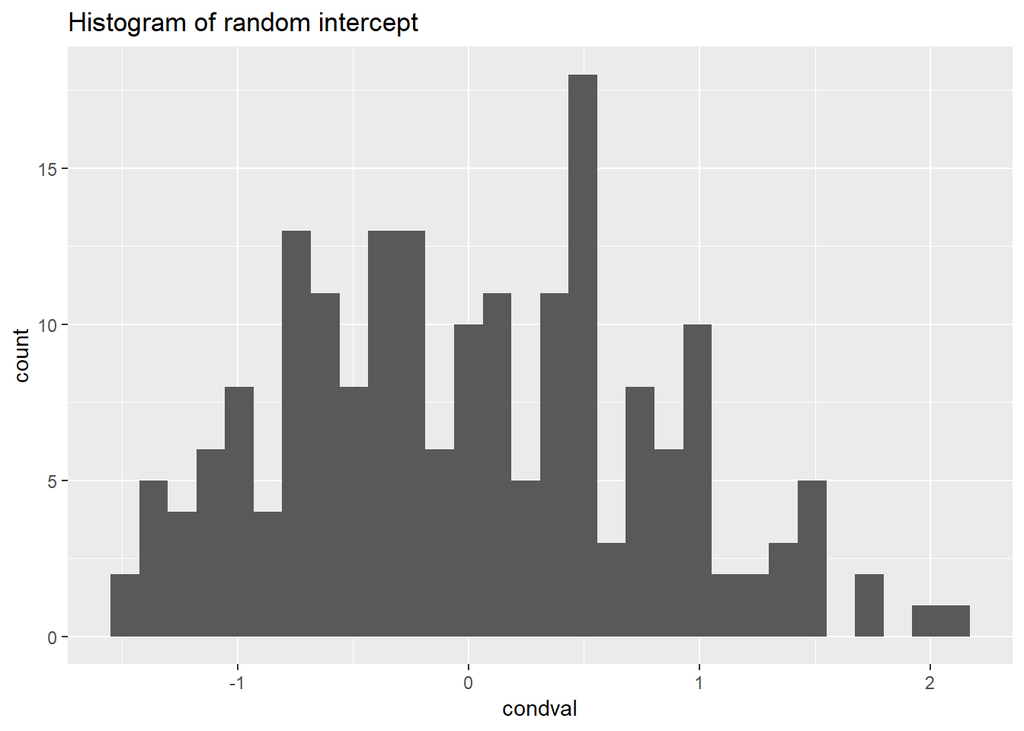

```r
ggplot(ran.d, aes(condval)) +
  geom_histogram(bins = 30) +
  ggtitle("Histogram of random intercept")
```

Next, we might check the distributional assumptions. We already have some information on this from the histograms, but QQ plots are helpful as well. The QQ plots indicate some non-normality, but it is not too extreme and probably close enough for inference.

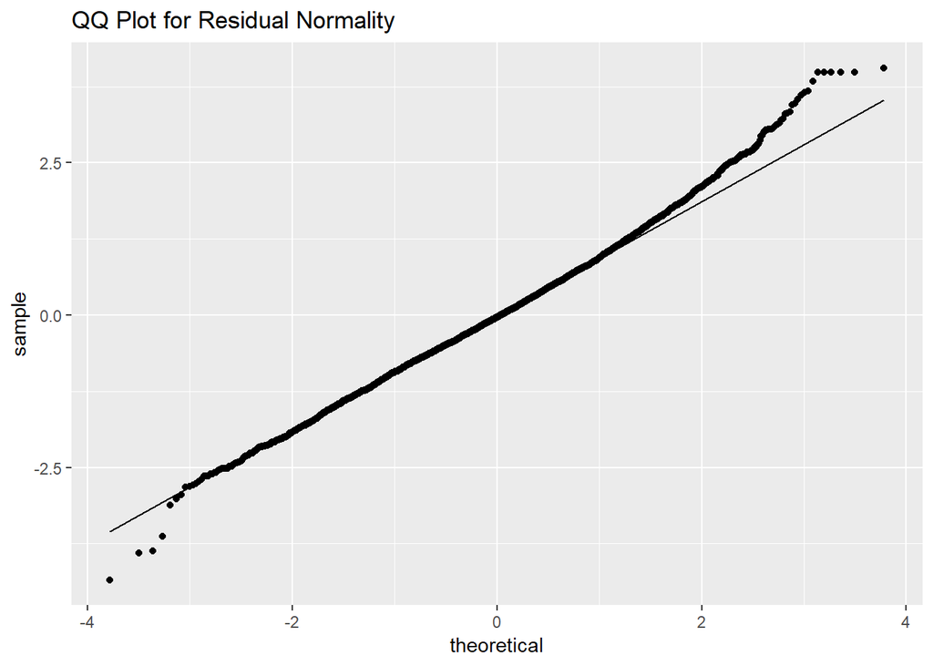

```r
ggplot(res.d, aes(sample = Residuals)) +
  stat_qq() + stat_qq_line() +
  ggtitle("QQ Plot for Residual Normality")
```

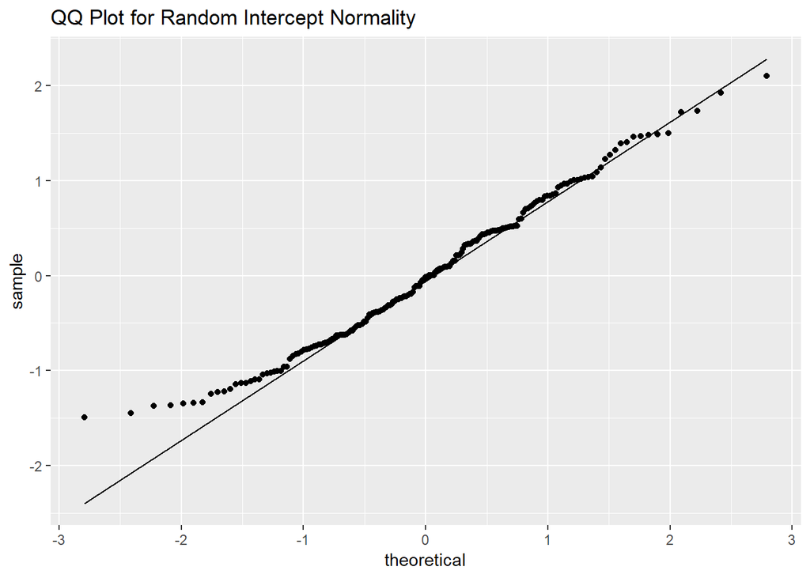

```r
ggplot(ran.d, aes(sample = condval)) +
  stat_qq() + stat_qq_line() +
  ggtitle("QQ Plot for Random Intercept Normality")
```

Finally, we check the homogeneity of variance. The residuals show a characteristic banding when there are floor and ceiling effects. At low predicted values, positive affect cannot be any lower than 1, so you have small or positive residuals. At high predicted values, positive affect cannot be greater than 5 so you have small positive or negative residuals. This is responsible for the straight, angled lines at the extremes. Its not particularly clear whether the residual variance changes much across levels of the predited value (Yhat) so its not terrible evidence against homogeneity of variance. Unless easy alternatives were available (they are not) one would probably proceed.

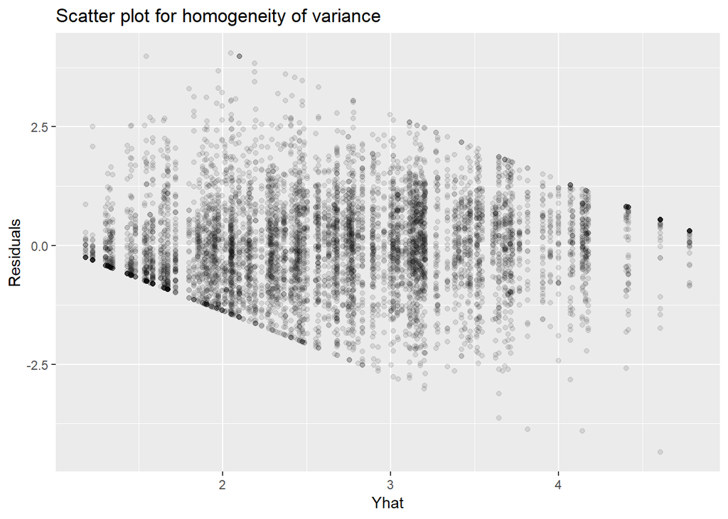

```r
ggplot(res.d, aes(Yhat, Residuals)) +
  geom_point(alpha = .1) +
  ggtitle("Scatter plot for homogeneity of variance")
```

## 2.2 Sample Write Up

An intercept only linear mixed model was fit to 6399 positive affect scores from 191 people. The intraclass correlation coefficient was 0.54 indicating that about half of the total variance in positive affect was between people and the other half is within person due to fluctuations across days. The fixed effect intercept revealed that the average [95% CI] positive affect was 2.68 [2.56, 2.79]. However, there were individual differences, with the standard deviation for the random intercept being 0.79 indicating that there are individual differences in the mean positive affect. Assuming the random intercepts follow a normal distribution, we expect most people to fall within one standard deviation of the mean, which in these data would be somewhere between: 1.89, 3.47.